# G3_Presentación

Autores/as

Abanto Romero, Jesus Alejandro (100%)

Cachique Moncada, Renato (100%)

Flores Guevara, Tamy Kristel (100%)

Llerena Silva, Nicolás Alejandro (0%)

Sobenes Obregon, Carlos Sebastian (100%)

Fecha de publicación

22 de febrero de 2026

# 1 Introducción

## 1.1 Relevancia

El COVID-19 impactó severamente la salud pública mundial. Analizamos casos sospechosos y confirmados en México (2021) usando datos epidemiológicos oficiales. Entender sus características y factores de gravedad es crucial para mejorar la respuesta ante futuras emergencias sanitarias.

## 1.2 Planificación

A continuación se presenta el cronograma de actividades realizado para este proyecto:

**Mostrar / ocultar código**

```
gantt
    dateFormat YYYY-MM-DD
    axisFormat %d/%m
    todayMarker off

    section Investigación y Diseño
    Definición del tema de investigación        :a1, 2026-01-05, 7d
    Definición de variables relevantes          :a2, 2026-01-12, 10d
    Creación de la herramienta de recolección   :a3, 2026-01-22, 10d

    section Análisis de Datos
    Análisis descriptivo de los datos           :b1, 2026-02-01, 9d
    Análisis de interacción                     :b2, 2026-02-10, 11d

    section Redacción
    Redacción de resultados e informe final     :d1, 2026-02-21, 9d
```

[output not shown]

## 1.3 Objetivos

### 1.3.1 Objetivo General

Analizar demográfica y clínicamente los casos de COVID-19 en México durante 2021.

# 2 Datos

## 2.1 Población objetivo

La población abarca todos los registros del Sistema de Vigilancia Epidemiológica sobre casos de COVID-19 en México (2021). La unidad muestral es el **individuo**.

## 2.2 Tipo de muestreo

Aplicamos muestreo no probabilístico por conveniencia, analizando la totalidad de observaciones validadas del archivo fuente.

## 2.3 Recolección de datos

Usamos el archivo `muestra_covid_500M_NA.csv`, una muestra didáctica del 2021 (Prado Urbano, 2026) extraída de Datos Abiertos de la DGE, que conserva variables clínicas validadas por la autoridad sanitaria.

## 2.4 Variables

Clasificación de variables seleccionadas:

**Tabla 1**  
*Descripción y clasificación de las variables seleccionadas para el estudio*

| # | Variable | Tipo Estadístico | Origen / Descripción |
| --- | --- | --- | --- |
| 1 | `SCORE_RIESGO_COVID` | Cuantitativa continua | **Derivada:** Índice continuo basado en la carga de comorbilidades y la certeza diagnóstica (Rango 0-3). Resume el nivel relativo de riesgo del paciente. |
| 2 | `INDICE_GRAVEDAD` | Cuantitativa continua | **Derivada:** Índice ponderado de complicaciones (neumonía, UCI, intubación) y defunción. Mide la severidad clínica del caso (Rango 0-1). |
| 3 | `N_COMORBILIDADES` | Cuantitativa discreta | **Derivada:** Suma simple de 10 comorbilidades crónicas (Diabetes, EPOC, Asma, etc.). Valor entero de 0 a 10. |
| 4 | `N_COMPLICACIONES_GRAVES` | Cuantitativa discreta | **Derivada:** Suma de eventos graves: NEUMONIA + INTUBADO + UCI. Indica severidad aguda (0 a 3). |
| 5 | `EDAD` | Cuantitativa discreta | **Original:** Edad del paciente en años completos. |
| 6 | `DIAS_RETRASO` | Cuantitativa discreta | **Derivada:** Diferencia en días entre `FECHA_INGRESO` y `FECHA_SINTOMAS`. Indica la demora en buscar atención médica. |
| 7 | `SEXO` | Cualitativa nominal | **Original:** Sexo del paciente (1: Mujer / 2: Hombre). |
| 8 | `ENTIDAD_RES` | Cualitativa nominal | **Original:** Entidad federativa de residencia (Códigos 1-32). |
| 9 | `ESTADO` | Cualitativa nominal | **Derivada:** Clasificación del desenlace final basada en si existe fecha de defunción (Vivo / Muerto). |
| 10 | `RIESGO_CLINICO` | Cualitativa ordinal | **Derivada:** Categorización del nº de comorbilidades en niveles jerárquicos: Muy bajo (0), Bajo (1-2), Moderado (3-4), Alto (5-6), Muy alto (7-8), Crítico (9-10). |
| 11 | `CLASIFICACION_FINAL` | Cualitativa ordinal | **Original:** Nivel de confirmación del caso (1-7), donde los valores más bajos indican mayor certeza diagnóstica (confirmado por lab, asociación, etc.). |

## 2.5 Limpieza

En esta sección se detalla la política de manejo de datos faltantes y la creación de variables derivadas.

### 2.5.1 Carga y Preprocesamiento

**Mostrar / ocultar código**

```r
if (!require("pacman")) install.packages("pacman")
pacman::p_load(dplyr, ggplot2, lubridate, knitr, tidyr, scales, e1071, kableExtra)
```

**Mostrar / ocultar código**

```r
# Carga de datos
DATOS_INICIALES <- read.csv("muestra_covid_500M_NA.csv")

# Transformación y Creación de Variables
DATOS_TRANSFORMADOS <- DATOS_INICIALES |>
  # Variable ESTADO
  mutate(ESTADO = if_else(is.na(FECHA_DEF), "Vivo", "Muerto")) |>
  # Limpieza EDAD
  mutate(EDAD = ifelse(EDAD == 0 | EDAD > 100, NA, EDAD)) |>
  # DIAS_RETRASO
  mutate(
    FECHA_INGRESO = as.Date(FECHA_INGRESO, format = "%Y-%m-%d"),
    FECHA_SINTOMAS = as.Date(FECHA_SINTOMAS, format = "%Y-%m-%d"),
    DIAS_RETRASO = as.numeric(FECHA_INGRESO - FECHA_SINTOMAS),
    DIAS_RETRASO = if_else(DIAS_RETRASO < 0, NA_real_, DIAS_RETRASO)
  ) |>
  # N_COMORBILIDADES
  mutate(
    N_COMORBILIDADES = rowSums(across(c(DIABETES, EPOC, ASMA, INMUSUPR,
                                        HIPERTENSION, CARDIOVASCULAR, OBESIDAD,
                                        RENAL_CRONICA, TABAQUISMO, OTRA_COM),
                                      ~ ifelse(.x == 1, 1, 0)), na.rm = TRUE)
  ) |>
  # SCORE_RIESGO_COVID
  mutate(
    CARGA_ENFERMEDAD = N_COMORBILIDADES / 10,
    FACTOR_CERTEZA = case_when(
        RESULTADO_LAB == 1 | RESULTADO_ANTIGENO == 1 ~ 3,
        RESULTADO_LAB == 2 | RESULTADO_ANTIGENO == 2 ~ 1,
        TRUE ~ 2
      ),
    SCORE_RIESGO_COVID = CARGA_ENFERMEDAD * FACTOR_CERTEZA,
    SCORE_RIESGO_COVID = ifelse(SCORE_RIESGO_COVID < 0 | SCORE_RIESGO_COVID > 3, NA, SCORE_RIESGO_COVID)
  ) |>
  # INDICE_GRAVEDAD
  mutate(
    NEUMONIA01 = case_when(NEUMONIA == 1 ~ 1, NEUMONIA == 2 ~ 0, TRUE ~ NA_real_),
    UCI01 = case_when(UCI == 1 ~ 1, UCI == 2 ~ 0, TRUE ~ NA_real_),
    INTUBADO01 = case_when(INTUBADO == 1 ~ 1, INTUBADO == 2 ~ 0, TRUE ~ NA_real_),
    DEFUNCION01 = case_when(ESTADO == "Muerto" ~ 1, ESTADO == "Vivo" ~ 0, TRUE ~ NA_real_),
    INDICE_GRAVEDAD = (1*NEUMONIA01 + 2*UCI01 + 3*INTUBADO01 + 4*DEFUNCION01) / 10,
    INDICE_GRAVEDAD = ifelse(INDICE_GRAVEDAD < 0 | INDICE_GRAVEDAD > 1, NA, INDICE_GRAVEDAD)
  ) |>
  # Limpieza ENTIDAD_RES y N_COMPLICACIONES
  mutate(
    ENTIDAD_RES = suppressWarnings(as.integer(ENTIDAD_RES)),
    ENTIDAD_RES = ifelse(ENTIDAD_RES %in% 1:32, ENTIDAD_RES, NA_integer_),
    N_COMPLICACIONES_GRAVES = (NEUMONIA == 1) + (INTUBADO == 1) + (UCI == 1),
    N_COMPLICACIONES_GRAVES = ifelse(N_COMPLICACIONES_GRAVES %in% 0:3, N_COMPLICACIONES_GRAVES, NA)
  ) |>
  # RIESGO_CLINICO
  mutate(
    RIESGO_CLINICO = case_when(
      N_COMORBILIDADES == 0 ~ "Muy bajo (0)",
      between(N_COMORBILIDADES, 1, 2) ~ "Bajo (1-2)",
      between(N_COMORBILIDADES, 3, 4) ~ "Moderado (3-4)",
      between(N_COMORBILIDADES, 5, 6) ~ "Alto (5-6)",
      between(N_COMORBILIDADES, 7, 8) ~ "Muy alto (7-8)",
      between(N_COMORBILIDADES, 9, 10) ~ "Crítico (9-10)",
      TRUE ~ NA_character_
    ),
    RIESGO_CLINICO = factor(RIESGO_CLINICO, levels = c("Muy bajo (0)", "Bajo (1-2)", "Moderado (3-4)", "Alto (5-6)", "Muy alto (7-8)", "Crítico (9-10)"), ordered = TRUE)
  ) |>
  # Limpieza CLASIFICACION_FINAL
  mutate(CLASIFICACION_FINAL = ifelse(CLASIFICACION_FINAL == 7, NA, CLASIFICACION_FINAL))
```

### 2.5.2 Manejo de Datos Faltantes (NAs)

A continuación, se cuantifican los valores perdidos y se aplica el filtro para obtener la muestra final (“DATOS_FINALES”), asegurando la calidad de la información analizada.

**Tabla 2**

*Conteo de valores perdidos por variable antes del filtrado*

**Mostrar / ocultar código**

```r
# 1. Selección de columnas de interés
cols_analisis <- c("EDAD", "SEXO", "DIAS_RETRASO", "ENTIDAD_RES",
                   "N_COMORBILIDADES", "SCORE_RIESGO_COVID", "INDICE_GRAVEDAD",
                   "N_COMPLICACIONES_GRAVES", "RIESGO_CLINICO", "CLASIFICACION_FINAL")

# 2. Diagnóstico previo (Conteo de NAs)
nas_por_columna <- colSums(is.na(DATOS_TRANSFORMADOS[cols_analisis]))
pct_nas <- round((nas_por_columna / nrow(DATOS_TRANSFORMADOS)) * 100, 2)

# Tabla de diagnóstico
data.frame(
  Variable = names(nas_por_columna),
  NAs_Cantidad = nas_por_columna,
  NAs_Porcentaje = paste0(pct_nas, "%")
) |>
  kbl() |>
  kable_styling(bootstrap_options = "striped", full_width = F)
```

|  | Variable | NAs_Cantidad | NAs_Porcentaje |
| --- | --- | --- | --- |
| EDAD | EDAD | 2429 | 0.49% |
| SEXO | SEXO | 200 | 0.04% |
| DIAS_RETRASO | DIAS_RETRASO | 401 | 0.08% |
| ENTIDAD_RES | ENTIDAD_RES | 200 | 0.04% |
| N_COMORBILIDADES | N_COMORBILIDADES | 0 | 0% |
| SCORE_RIESGO_COVID | SCORE_RIESGO_COVID | 0 | 0% |
| INDICE_GRAVEDAD | INDICE_GRAVEDAD | 468238 | 93.65% |
| N_COMPLICACIONES_GRAVES | N_COMPLICACIONES_GRAVES | 599 | 0.12% |
| RIESGO_CLINICO | RIESGO_CLINICO | 0 | 0% |
| CLASIFICACION_FINAL | CLASIFICACION_FINAL | 342317 | 68.46% |

**Tabla 3**

*Resumen del impacto de la limpieza de datos*

**Mostrar / ocultar código**

```r
# 3. Ejecución del Filtrado
n_antes <- nrow(DATOS_TRANSFORMADOS)
DATOS_FINALES <- DATOS_TRANSFORMADOS |>
  filter(complete.cases(across(all_of(cols_analisis))))
n_despues <- nrow(DATOS_FINALES)

# 4. Tabla de Balance de Limpieza
data.frame(
  Fase = c("Total Registros Iniciales", "Registros Eliminados (Incompletos)", "Muestra Final Analizable"),
  Cantidad = c(format(n_antes, big.mark=","), format(n_antes - n_despues, big.mark=","), format(n_despues, big.mark=",")),
  Porcentaje = c("100%", paste0(round((n_antes - n_despues)/n_antes*100, 2), "%"), paste0(round(n_despues/n_antes*100, 2), "%"))
) |>
  kbl() |>
  kable_styling(bootstrap_options = "hover", full_width = F)
```

| Fase | Cantidad | Porcentaje |
| --- | --- | --- |
| Total Registros Iniciales | 500,000 | 100% |
| Registros Eliminados (Incompletos) | 482,096 | 96.42% |
| Muestra Final Analizable | 17,904 | 3.58% |

# 3 Análisis Descriptivo

## 3.1 Análisis Univariado

### 3.1.1 Variable Cuantitativa: Score de Riesgo COVID

Analizamos la distribución del riesgo acumulado en la población.

**Tabla 4**  
*Estadísticos descriptivos: Distribución del score de Riesgo COVID*

**Mostrar / ocultar código**

```r
# Estadísticos descriptivos
desc_score <- DATOS_FINALES |>
  summarise(
    Media = mean(SCORE_RIESGO_COVID),
    Mediana = median(SCORE_RIESGO_COVID),
    Desv.Std = sd(SCORE_RIESGO_COVID),
    Min = min(SCORE_RIESGO_COVID),
    Max = max(SCORE_RIESGO_COVID)
  )

kbl(desc_score, digits = 2) |>
  kable_styling(full_width = F)
```

| Media | Mediana | Desv.Std | Min | Max |
| --- | --- | --- | --- | --- |
| 0.32 | 0.3 | 0.34 | 0 | 2.7 |

**Figura 2**  
*Distribución del score de riesgo COVID en la población estudiada*

**Mostrar / ocultar código**

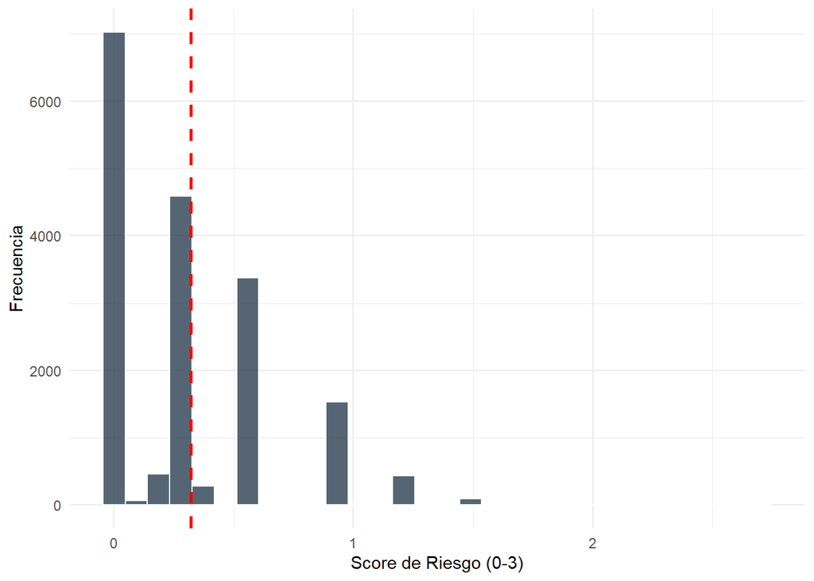

```r
# Histograma
ggplot(DATOS_FINALES, aes(x = SCORE_RIESGO_COVID)) +
  geom_histogram(bins = 30, fill = "#2C3E50", color = "white", alpha = 0.8) +
  geom_vline(aes(xintercept = mean(SCORE_RIESGO_COVID)), color = "red", linetype = "dashed", size = 1) +
  labs(
    x = "Score de Riesgo (0-3)",
    y = "Frecuencia"
  ) +
  theme_minimal()
```

Nota. La línea roja vertical discontinua representa el valor promedio del score de riesgo COVID.

> **Interpretación:** La mayoría de los casos presentan un score de riesgo bajo a moderado (concentración a la izquierda). La asimetría positiva sugiere que los pacientes con múltiples factores de riesgo y certeza diagnóstica alta son menos frecuentes pero representan el grupo crítico.

### 3.1.2 Variable Cuantitativa: Índice de Gravedad

Evaluamos la severidad clínica de los casos.

**Figura 3**  
*Distribución del Índice de Gravedad*

**Mostrar / ocultar código**

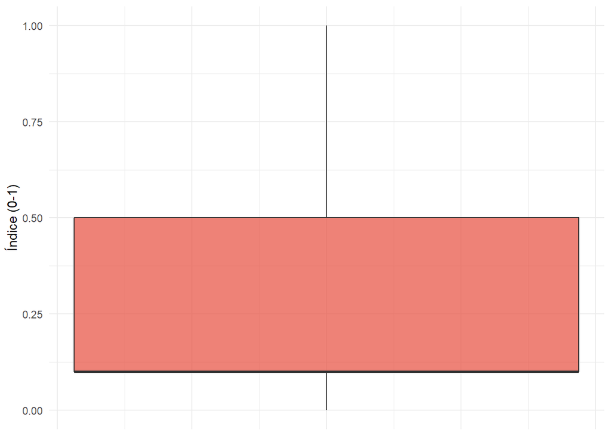

```r
# Boxplot para visualizar outliers y distribución
ggplot(DATOS_FINALES, aes(y = INDICE_GRAVEDAD)) +
  geom_boxplot(fill = "#E74C3C", alpha = 0.7) +
  labs(
    y = "Índice (0-1)"
  ) +
  theme_minimal() +
  theme(axis.text.x = element_blank())
```

### 3.1.3 Variable Cualitativa: Sexo

Distribución de la muestra según género.

**Tabla 5**  
*Distribución de casos por Sexo*

**Mostrar / ocultar código**

```r
# Tabla de frecuencias
tabla_sexo <- DATOS_FINALES |>
  group_by(SEXO) |>
  summarise(
    Frecuencia = n(),
    Porcentaje = n() / nrow(DATOS_FINALES) * 100
  ) |>
  mutate(Etiqueta = ifelse(SEXO == 1, "Mujer", "Hombre"))

kbl(tabla_sexo, digits = 1) |>
  kable_styling(full_width = F)
```

| SEXO | Frecuencia | Porcentaje | Etiqueta |
| --- | --- | --- | --- |
| 1 | 7648 | 42.7 | Mujer |
| 2 | 10256 | 57.3 | Hombre |

**Figura 4**  
*Distribución de casos por Sexo*

**Mostrar / ocultar código**

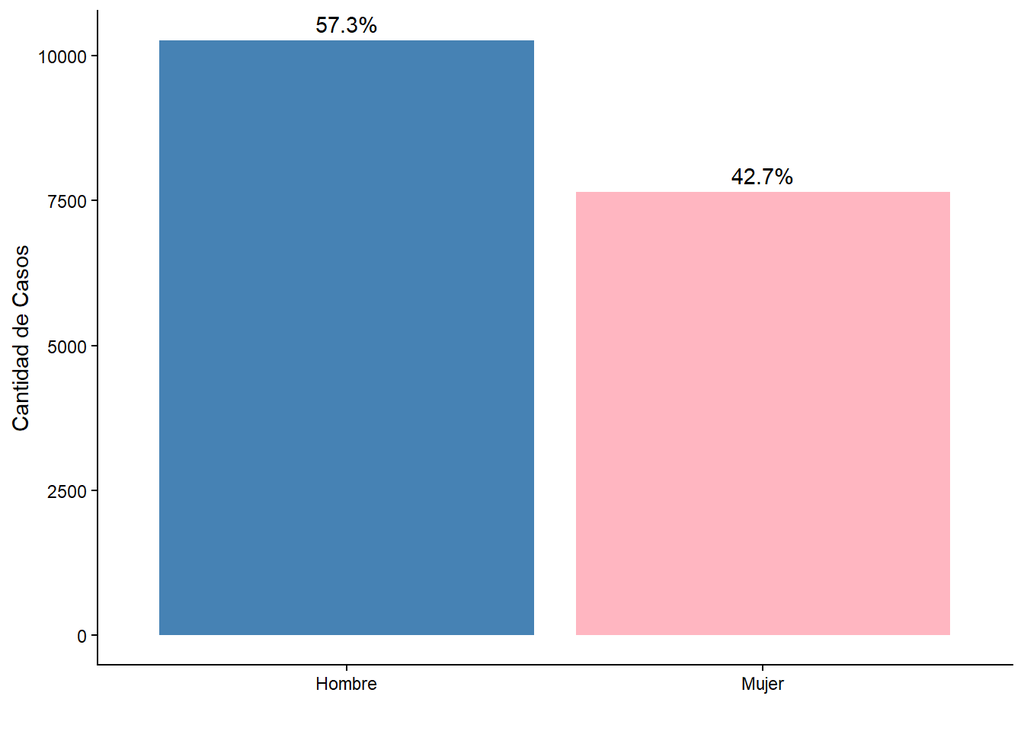

```r
# Gráfico de barras
ggplot(tabla_sexo, aes(x = Etiqueta, y = Frecuencia, fill = Etiqueta)) +
  geom_col(show.legend = FALSE) +
  geom_text(aes(label = paste0(round(Porcentaje, 1), "%")), vjust = -0.5) +
  scale_fill_manual(values = c("steelblue", "lightpink")) +
  labs(
    x = "", y = "Cantidad de Casos"
  ) +
  theme_classic()
```

> **Interpretación:** En la muestra analizada se observa una ligera preponderancia de casos en hombres respecto a mujeres, lo que representa una distribución moderadamente asimétrica por sexo, aunque sin alcanzar una diferencia extrema.

## 3.2 Analisis de Interaccion

### 3.2.1 Variables Categóricas: SEXO vs ESTADO

**Tabla 6**  
*Distribución de casos por Sexo y Estado*

**Mostrar / ocultar código**

```r
# Crear tabla de contingencia
tabla_categorica <- table(DATOS_FINALES$SEXO, DATOS_FINALES$ESTADO)
colnames(tabla_categorica) <- c("Vivo", "Muerto")
rownames(tabla_categorica) <- c("Mujer", "Hombre")

# Mostrar tabla con kable
kbl(tabla_categorica,
    caption = "Frecuencias absolutas: Sexo vs Estado",
    align = 'c') |>
  kable_styling(bootstrap_options = "striped", full_width = FALSE)
```

Frecuencias absolutas: Sexo vs Estado

[output not shown]

**Tabla 7**  
*Porcentajes por Sexo*

**Mostrar / ocultar código**

```r
# Calcular porcentajes por fila
prop_tabla <- prop.table(tabla_categorica, 1) * 100
kbl(round(prop_tabla, 1),
    caption = "Porcentajes por fila (%)",
    align = 'c') |>
  kable_styling(bootstrap_options = "striped", full_width = FALSE)
```

Porcentajes por fila (%)

[output not shown]

**Figura 5**  
*Distribución del Estado por Sexo*

**Mostrar / ocultar código**

[figure not shown]

```r
# Gráfico de barras agrupadas
barplot(tabla_categorica,
        beside = TRUE,
        col = c("lightblue", "pink"),
        main = "Distribución del Estado por Sexo",
        xlab = "Estado",
        ylab = "Número de casos",
        legend.text = rownames(tabla_categorica),
        args.legend = list(x = "topright", title = "Sexo", cex = 0.8))
```

**Figura 6**  
*Distribución del Estado según Sexo*  
Frecuencia absoluta de casos

**Mostrar / ocultar código**

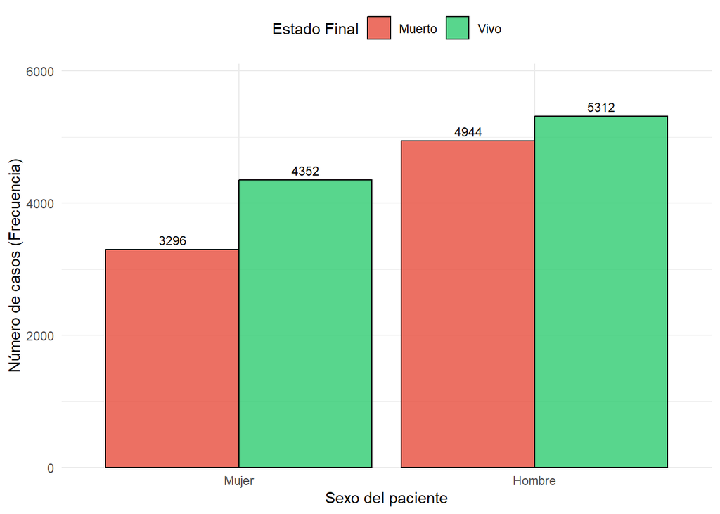

```r
# Gráfico de barras agrupadas con ggplot2
ggplot(DATOS_FINALES, aes(x = factor(SEXO, labels = c("Mujer", "Hombre")), fill = ESTADO)) +
  geom_bar(position = "dodge", color = "black", alpha = 0.8) +
  geom_text(stat = 'count', aes(label = ..count..),
            position = position_dodge(width = 0.9), vjust = -0.5, size = 3) +
  scale_fill_manual(values = c("Muerto" = "#E74C3C", "Vivo" = "#2ECC71")) +

  scale_y_continuous(expand = expansion(mult = c(0, 0.15))) +
  labs(
    x = "Sexo del paciente",
    y = "Número de casos (Frecuencia)",
    fill = "Estado Final"
  ) +
  theme_minimal() +
  theme(legend.position = "top")
```

### 3.2.2 Variables Numéricas: EDAD vs DIAS_RETRASO

**Tabla 8**  
*Estadísticas descriptivas y correlación entre variables numéricas*

**Mostrar / ocultar código**

```r
# Calcular correlación PRIMERO
cor_edad_retraso <- cor(DATOS_FINALES$EDAD, DATOS_FINALES$DIAS_RETRASO,
                        use = "complete.obs")

# Tabla con estadísticas de AMBAS variables y su relación
resumen_numericas <- data.frame(
  " " = c("EDAD (años)", "DIAS_RETRASO (días)", "CORRELACIÓN"),
  "Media" = c(
    round(mean(DATOS_FINALES$EDAD, na.rm = TRUE), 1),
    round(mean(DATOS_FINALES$DIAS_RETRASO, na.rm = TRUE), 1),
    paste("r =", round(cor_edad_retraso, 3))
  ),
  "DE" = c(
    round(sd(DATOS_FINALES$EDAD, na.rm = TRUE), 1),
    round(sd(DATOS_FINALES$DIAS_RETRASO, na.rm = TRUE), 1),
    ""
  ),
  "Mínimo" = c(
    min(DATOS_FINALES$EDAD, na.rm = TRUE),
    min(DATOS_FINALES$DIAS_RETRASO, na.rm = TRUE),
    ""
  ),
  "Máximo" = c(
    max(DATOS_FINALES$EDAD, na.rm = TRUE),
    max(DATOS_FINALES$DIAS_RETRASO, na.rm = TRUE),
    ""
  )

)

kbl(resumen_numericas,
    caption = "Análisis de la relación Edad vs Días de Retraso",
    col.names = c("Variable", "Media", "Desv. Estándar", "Mín", "Máx")) |>
  kable_styling(bootstrap_options = "striped", full_width = FALSE)
```

Análisis de la relación Edad vs Días de Retraso

| Variable | Media | Desv. Estándar | Mín | Máx |
| --- | --- | --- | --- | --- |
| EDAD (años) | 56.9 | 18 | 1 | 100 |
| DIAS_RETRASO (días) | 5.7 | 4.1 | 0 | 45 |
| CORRELACIÓN | r = 0.045 |  |  |  |

**Figura 7**  
*Edad vs Días de Retraso*

**Mostrar / ocultar código**

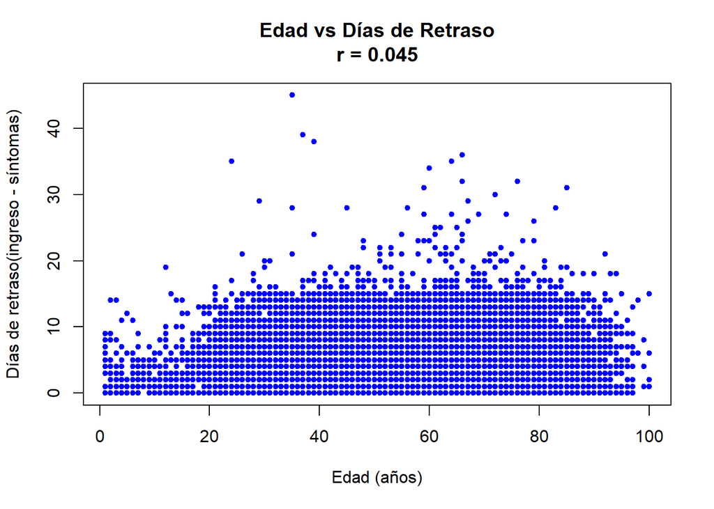

```r
# Gráfico básico de dispersión
plot(DATOS_FINALES$EDAD, DATOS_FINALES$DIAS_RETRASO,
     pch = 20,
     col = "blue",
     main = paste("Edad vs Días de Retraso\nr =", round(cor_edad_retraso, 3)),
     xlab = "Edad (años)",
     ylab = "Días de retraso(ingreso - síntomas)")
```

**Mostrar / ocultar código**

```r
# Calcular correlación para incluir en el título
cor_edad_retraso <- cor(DATOS_FINALES$EDAD, DATOS_FINALES$DIAS_RETRASO,
                        use = "complete.obs")
```

> **Interpretación:** El gráfico de dispersión ilustra la relación bivariada empírica entre la edad de los pacientes y los días que demoraron en buscar atención hospitalaria. Visualmente, la distribución de los puntos azules forma una nube dispersa y homogénea, sin evidenciar ninguna tendencia ascendente o descendente clara. Esta ausencia de un patrón lineal, respaldada por un coeficiente de correlación cercano a cero, demuestra de forma inicial que el tiempo de espera para acudir al hospital fue indistinto para todos los grupos de edad.

Coeficiente de correlacion:

**Mostrar / ocultar código**

```r
round(cor_edad_retraso, 3)
```

```
[1] 0.045
```

**Figura 8**  
*Densidad: Edad vs Días de Retraso*

**Mostrar / ocultar código**

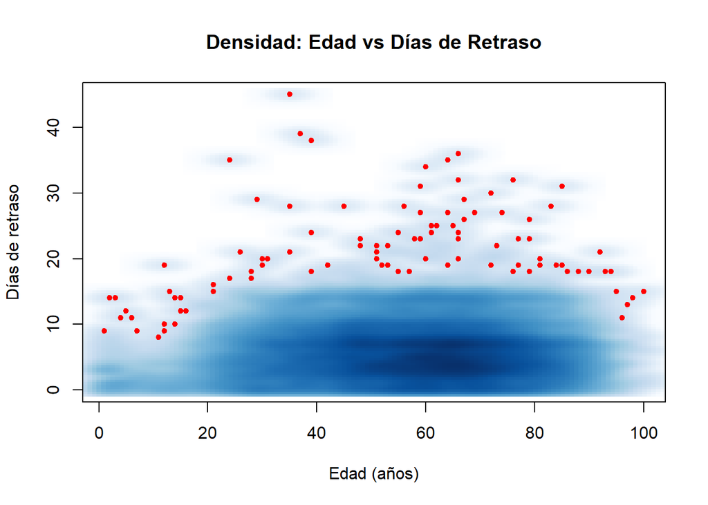

```r
  smoothScatter(DATOS_FINALES$EDAD, DATOS_FINALES$DIAS_RETRASO,
              pch = 20,
              col = "red",
              main = "Densidad: Edad vs Días de Retraso",
              xlab = "Edad (años)",
              ylab = "Días de retraso")
```

> **Interpretación:** A diferencia de la dispersión clásica, este gráfico de densidad revela las zonas de mayor concentración masiva de pacientes. Se observa claramente que el área de mayor densidad (la franja horizontal más oscura) se localiza en la parte inferior del eje Y (entre 0 y 10 días de retraso) y se extiende de manera uniforme a lo largo de casi todas las edades. Esto confirma visualmente que la inmensa mayoría de la población, sin importar si eran jóvenes o adultos mayores, acudió a recibir atención médica durante los primeros días tras el inicio de los síntomas, reafirmando que no existe una dependencia lineal entre la edad y el tiempo de espera.

### 3.2.3 Variables Categórica Y Numérica: RIESGO_CLINICO vs INDICE_GRAVEDAD

**Tabla 9**  
*Estadísticos del Índice de Gravedad por Nivel de Riesgo*

**Mostrar / ocultar código**

```r
# Resumen estadístico por grupo (igual que antes)
resumen_riesgo <- DATOS_FINALES |>
  group_by(RIESGO_CLINICO) |>
  summarise(
    n = n(),
    Media = round(mean(INDICE_GRAVEDAD), 3),
    Mediana = round(median(INDICE_GRAVEDAD), 3),
    DE = round(sd(INDICE_GRAVEDAD), 3),
    Min = round(min(INDICE_GRAVEDAD), 3),
    Max = round(max(INDICE_GRAVEDAD), 3)
  )

kbl(resumen_riesgo,
    caption = "Resumen por grupo de riesgo",
    align = c('l', rep('r', 6))) |>
  kable_styling(bootstrap_options = "striped", full_width = FALSE)
```

Resumen por grupo de riesgo

| RIESGO_CLINICO | n | Media | Mediana | DE | Min | Max |
| --- | --- | --- | --- | --- | --- | --- |
| Muy bajo (0) | 7024 | 0.246 | 0.1 | 0.261 | 0 | 1.0 |
| Bajo (1-2) | 8618 | 0.315 | 0.4 | 0.271 | 0 | 1.0 |
| Moderado (3-4) | 2123 | 0.338 | 0.4 | 0.267 | 0 | 1.0 |
| Alto (5-6) | 134 | 0.343 | 0.4 | 0.278 | 0 | 1.0 |
| Muy alto (7-8) | 4 | 0.125 | 0.0 | 0.250 | 0 | 0.5 |
| Crítico (9-10) | 1 | 0.000 | 0.0 | NA | 0 | 0.0 |

**Figura 9**  
*Distribución del Índice de Gravedad por Nivel de Riesgo*

**Mostrar / ocultar código**

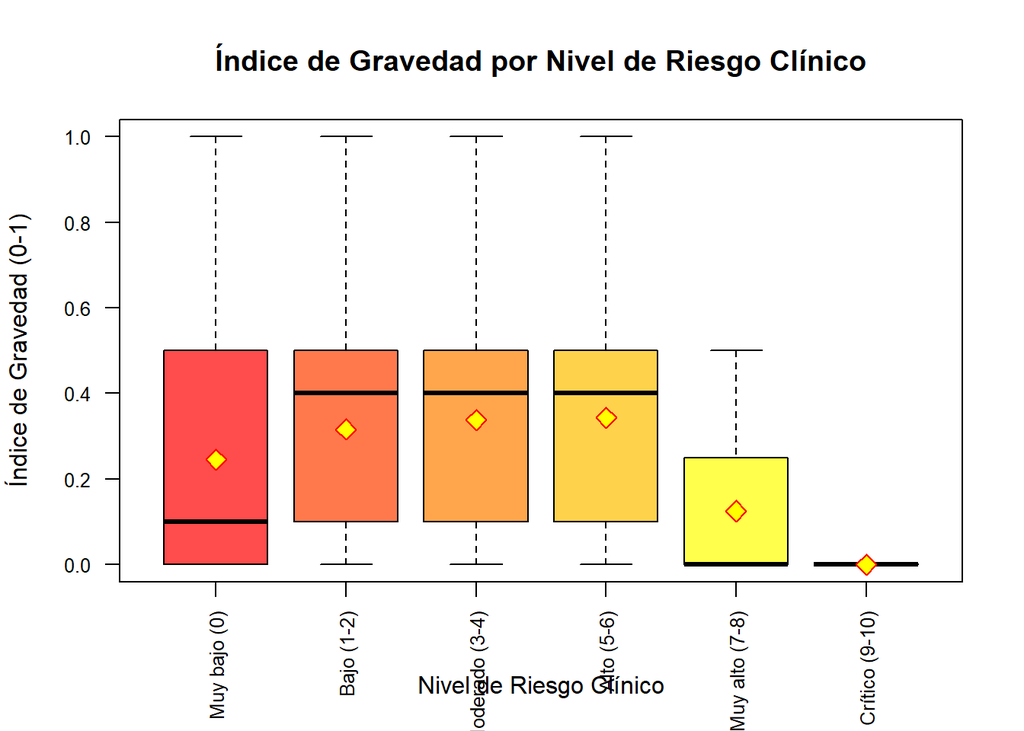

```r
# Boxplot por categoría - USANDO TU ESTILO (base R)
boxplot(INDICE_GRAVEDAD ~ RIESGO_CLINICO, data = DATOS_FINALES,
        col = heat.colors(6, alpha = 0.7),
        main = "Índice de Gravedad por Nivel de Riesgo Clínico",
        xlab = "Nivel de Riesgo Clínico",
        ylab = "Índice de Gravedad (0-1)",
        las = 2,  # Etiquetas verticales en eje X
        cex.axis = 0.8)

# Agregar puntos de las medias
means <- tapply(DATOS_FINALES$INDICE_GRAVEDAD, DATOS_FINALES$RIESGO_CLINICO, mean)
points(1:length(means), means, pch = 23, col = "red", bg = "yellow", cex = 1.5)
```

# 4 Análisis Probabilístico

## 4.1 Probabilidad Empírica

### 4.1.1 Nivel de Riesgo Clínico

- **Experimento:** Seleccionar un paciente al azar de la muestra y observar su categoría de riesgo clínico.
- **Identificación de Eventos Atómicos:** Definimos los siguientes eventos mutuamente excluyentes:
  - $E_1$: Seleccionar un paciente con riesgo clínico “Muy bajo”.
  - $E_2$: Seleccionar un paciente con riesgo clínico “Bajo”.
  - $E_3$: Seleccionar un paciente con riesgo clínico “Moderado”.
  - $E_4$: Seleccionar un paciente con riesgo clínico “Alto”.
  - $E_5$: Seleccionar un paciente con riesgo clínico “Muy alto”.
  - $E_6$: Seleccionar un paciente con riesgo clínico “Crítico”.
- **Espacio Muestral** ($\Omega_1$):
  $$\Omega_1 = \{ \text{Muy bajo}, \text{Bajo}, \text{Moderado}, \text{Alto}, \text{Muy alto}, \text{Crítico} \}$$

**Tabla 10**

*Probabilidad Empírica: Riesgo Clínico*

**Mostrar / ocultar código**

```r
# Tabla Variable 1: RIESGO
tabla_riesgo <- DATOS_FINALES |>
  group_by(RIESGO_CLINICO) |>
  summarise(
    fi = n(),
    Pi = n() / nrow(DATOS_FINALES)
  ) |>
  mutate(Porcentaje = paste0(round(Pi * 100, 2), "%"))

kbl(tabla_riesgo,
    col.names = c("Nivel de Riesgo", "Frecuencia", "Probabilidad", "%"),
    align = "c", caption = NULL) |>
  kable_styling(bootstrap_options = "striped", full_width = F)
```

| Nivel de Riesgo | Frecuencia | Probabilidad | % |
| --- | --- | --- | --- |
| Muy bajo (0) | 7024 | 0.3923146 | 39.23% |
| Bajo (1-2) | 8618 | 0.4813450 | 48.13% |
| Moderado (3-4) | 2123 | 0.1185769 | 11.86% |
| Alto (5-6) | 134 | 0.0074844 | 0.75% |
| Muy alto (7-8) | 4 | 0.0002234 | 0.02% |
| Crítico (9-10) | 1 | 0.0000559 | 0.01% |

A partir del cálculo empírico, observamos que los eventos con mayor probabilidad de ocurrencia corresponden a los niveles de riesgo “Muy bajo” y “Bajo”. Esto indica que, si seleccionamos a un paciente al azar de nuestra muestra, es altamente probable que este no presente una carga severa de comorbilidades previas. Por el contrario, la probabilidad de ocurrencia del evento $E_6$ (Riesgo Crítico) es marginal, demostrando que los casos con acumulación extrema de factores de riesgo representan una fracción muy pequeña y atípica de la población estudiada.

### 4.1.2 Estado del Paciente

- **Experimento:** Seleccionar un paciente al azar de la muestra y observar su desenlace final.
- **Identificación de Eventos Atómicos:**
  - $S_1$: Seleccionar un paciente cuyo desenlace final es “Vivo”.
  - $S_2$: Seleccionar un paciente cuyo desenlace final es “Muerto”.
- **Espacio Muestral (**$\Omega_2$):

  $$\Omega_2 = \{ \text{Vivo}, \text{Muerto} \}$$

**Tabla 11**

*Probabilidad Empírica: Estado Final*

**Mostrar / ocultar código**

```r
# Tabla Variable 2: ESTADO
tabla_estado <- DATOS_FINALES |>
  group_by(ESTADO) |>
  summarise(
    fi = n(),
    Pi = n() / nrow(DATOS_FINALES)
  ) |>
  mutate(Porcentaje = paste0(round(Pi * 100, 2), "%"))

kbl(tabla_estado,
    col.names = c("Estado", "Frecuencia", "Probabilidad", "%"),
    align = "c", caption = NULL) |>
  kable_styling(bootstrap_options = "striped", full_width = F)
```

| Estado | Frecuencia | Probabilidad | % |
| --- | --- | --- | --- |
| Muerto | 8240 | 0.4602324 | 46.02% |
| Vivo | 9664 | 0.5397676 | 53.98% |

El espacio muestral dicotómico revela las probabilidades empíricas absolutas de supervivencia y mortalidad en esta base de datos filtrada. Comparar $P(S_1)$ frente a $P(S_2)$ nos proporciona la tasa de letalidad general (o “probabilidad de fracaso”) que nos servirá como tasa base o parámetro a priori para los modelos probabilísticos posteriores, como el Teorema de Bayes y la distribución de Bernoulli.

## 4.2 Probabilidad Condicional

- **Evento** $A$: Seleccionar un paciente que **Fallece** (Variable `ESTADO` = “Muerto”).
- **Evento** $B$: Seleccionar un paciente que tiene **Riesgo Bajo** (Variable `RIESGO_CLINICO` = “Bajo (1-2)”).

**Mostrar / ocultar código**

```r
# --- CÁLCULOS ---
n_total <- nrow(DATOS_FINALES)

# 1. Probabilidades Marginales
f_A <- DATOS_FINALES |> filter(ESTADO == "Muerto") |> nrow()
P_A <- f_A / n_total

f_B <- DATOS_FINALES |> filter(RIESGO_CLINICO == "Bajo (1-2)") |> nrow()
P_B <- f_B / n_total

# 2. Intersección (Probabilidad Conjunta P(A y B))
f_interseccion <- DATOS_FINALES |>
  filter(ESTADO == "Muerto", RIESGO_CLINICO == "Bajo (1-2)") |>
  nrow()
P_Interseccion <- f_interseccion / n_total

# 3. Probabilidad Condicional Directa P(A|B) (Verosimilitud)
P_A_dado_B <- ifelse(P_B > 0, P_Interseccion / P_B, 0)
```

### 4.2.1 Propiedades de la probabilidad

- Calculamos la probabilidad de que ocurran ambos eventos simultáneamente (que el paciente fallezca **y** tenga riesgo bajo):

  $$P(A \cap B) = 0.2415$$
- Calculamos la probabilidad de que un paciente **sobreviva** ($A^C$) y la probabilidad de que **no** pertenezca al grupo de riesgo bajo ($B^C$):

  $$P(A^C) = 1 - P(A) = 1 - 0.4602 = 0.5398$$

  $$P(B^C) = 1 - P(B) = 1 - 0.4813 = 0.5187$$
- Calculamos la probabilidad de que ocurra al menos uno de los dos eventos ($A \cup B$):

  $$P(A \cup B) = P(A) + P(B) - P(A \cap B)$$

  $$P(A \cup B) = 0.4602 + 0.4813 - 0.2415 = 0.7001$$
- Calculamos la probabilidad de que un paciente tenga riesgo bajo, pero **no** fallezca (es decir, sobreviva). Esto corresponde a la intersección del complemento de $A$ con $B$ ($A^C \cap B$):

  $$P(A^C \cap B) = P(B) - P(A \cap B)$$

  $$P(A^C \cap B) = 0.4813 - 0.2415 = 0.2398$$
- Calculamos la probabilidad de que fallezca y **no** tenga riesgo bajo ($A \cap B^C$):

  $$P(A \cap B^C) = P(A) - P(A \cap B) = 0.4602 - 0.2415 = 0.2187$$
- Calculamos la probabilidad de que el paciente NO fallezca y NO pertenezca al grupo de riesgo bajo (es decir, sobreviva y tenga otro riesgo distinto a “Bajo”):

  $$P(A^C \cap B^C) = P((A \cup B)^C) = 1 - P(A \cup B)$$

  $$P(A^C \cap B^C) = 1 - 0.7001 = 0.2999$$

### 4.2.2 Prueba de Independencia

Dos eventos son estadísticamente independientes si se cumple que:

$$P(A \cap B) = P(A) \cdot P(B)$$

Sustituyendo con nuestros datos:

- **Probabilidad Conjunta :**

  $$P(A \cap B) = 0.2415$$
- **Producto de Marginales :**

  $$P(A) \cdot P(B) = 0.4602 \cdot 0.4813 = 0.2215$$

Entonces $A$ y $B$ no son independientes.

#### 4.2.2.1 Argumento Gráfico de Independencia

Para respaldar nuestra prueba numérica, visualizamos la relación entre ambas variables mediante un gráfico de mosaico. Si los eventos fueran independientes, las divisiones horizontales (Vivos/Muertos) se mantendrían al mismo nivel en todas las columnas verticales (Niveles de riesgo).

**Figura 10**  
*Mosaico de Independencia: Riesgo Clínico vs Estado*

**Mostrar / ocultar código**

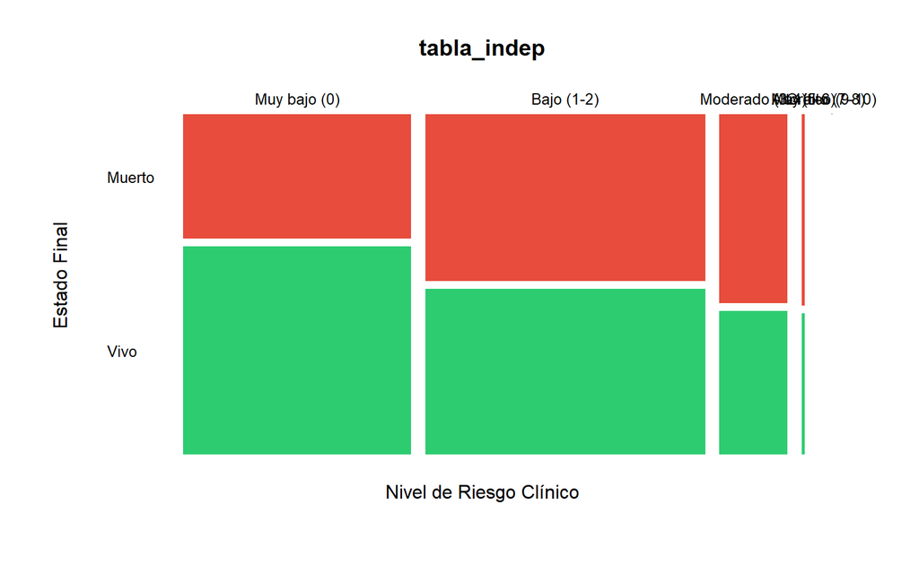

```r
tabla_indep <- table(DATOS_FINALES$RIESGO_CLINICO, DATOS_FINALES$ESTADO)

mosaicplot(tabla_indep,
           xlab = "Nivel de Riesgo Clínico", ylab = "Estado Final",
           color = c("#E74C3C", "#2ECC71"), # Rojo para Muerto, Verde para Vivo
           border = "white", las = 1, cex.axis = 0.8)
```

### 4.2.3 Probabilidad Condicional Directa

Calculamos la probabilidad condicional de que un paciente fallezca ($A$), dado que sabemos previamente que pertenece al grupo de Riesgo Bajo ($B$).

Utilizamos la fórmula general de probabilidad condicional:

$$P(A|B) = \frac{P(A \cap B)}{P(B)}$$

Sustituyendo con nuestros datos empíricos:

$$P(A|B) = \frac{0.2415}{0.4813} = 0.5017$$

### 4.2.4 Teorema de Bayes y Probabilidad Total

Deseamos calcular la probabilidad a posteriori $P(B|A)$: *Si sabemos que un paciente ha fallecido, ¿cuál es la probabilidad de que perteneciera al grupo de Riesgo Bajo?*

Fórmula de Bayes:

$$P(B|A) = \frac{P(A|B) \cdot P(B)}{P(A)}$$

**Paso 1: Desarrollo de la Probabilidad Total (Denominador)**

Calculamos $P(A)$ (Probabilidad total de morir) sumando las probabilidades ponderadas de todos los niveles de riesgo ($E_1$ a $E_6$):

$$P(A) = \sum_{i=1}^{6} P(A \mid E_i)\cdot P(E_i)$$

**Mostrar / ocultar código**

```r
# Cálculo de la Probabilidad Total sumando cada grupo
tabla_total <- DATOS_FINALES |>
  group_by(RIESGO_CLINICO) |>
  summarise(
    P_Ei = n() / n_total,                                    # P(Ei) - A priori
    P_A_dado_Ei = sum(ESTADO == "Muerto") / n()       # P(A | Ei) - Verosimilitud
  )

# Realizamos la suma de productos
P_Total_Calculada <- sum(tabla_total$P_Ei * tabla_total$P_A_dado_Ei)
```

Al sumar las probabilidades condicionales parciales, obtenemos:

$$P(A) = 0.4602$$

**Paso 2: Aplicación Final de Bayes**

Sustituimos en la fórmula principal:

$$P(B|A) = \frac{P(A|B)\cdot P(B)}{P(A_{Total})} = \frac{0.5017 \cdot 0.4813}{0.4602} = 0.5248$$

El análisis conjunto de estos eventos demuestra de manera concluyente que el fallecimiento por COVID-19 y el nivel de riesgo clínico basal **no son eventos independientes** en nuestra población de estudio. La ocurrencia de uno afecta matemáticamente la probabilidad del otro.

Por un lado, la **Probabilidad Condicional Directa** ($P(A|B) = 50.17\%$) nos revela la letalidad específica a la que se enfrenta un paciente “sano” (con riesgo bajo); es decir, su riesgo real de perder la vida a pesar de tener pocas comorbilidades.

## 4.3 Variables Aleatorias Discretas

### 4.3.1 ESTADO

Utilizaremos la variable empírica `ESTADO` para estimar la probabilidad de éxito y evaluar una variable aleatoria discreta Binomial.

- **Definición del Éxito:** Que un paciente seleccionado al azar sobreviva al egreso hospitalario (ESTADO = “Vivo”).
- **Experimento:** Extraer una nueva muestra aleatoria de 40 pacientes confirmados con COVID-19 y registrar cuántos de ellos logran sobrevivir.
- **Variable aleatoria ($Y$):**
  $$Y = \text{Número de pacientes que sobreviven en una muestra de tamaño } n=40$$
- **Modelo candidato:** **La variable $Y$ se distribuye como una Binomial** porque consiste en $n$ ensayos idénticos e independientes, donde cada paciente evaluado tiene solo dos posibles desenlaces mutuamente excluyentes (sobrevive o fallece), y la probabilidad de éxito ($p$) se asume constante para todos los ensayos.
  $$Y \sim \text{Binomial}(n=40, p)$$

#### 4.3.1.1 Cálculo del Parámetro ($p$)

**Mostrar / ocultar código**

```r
# Cálculo de la probabilidad de éxito (p) en la población total
p_exito <- mean(DATOS_FINALES$ESTADO == "Vivo")
cat("Probabilidad de éxito estimada (p):", round(p_exito, 4), "\n")
```

```
Probabilidad de éxito estimada (p): 0.5398
```

#### 4.3.1.2 Ejemplos de Aplicación (Cálculo de Probabilidades)

A continuación, demostramos la utilidad del modelo resolviendo casos prácticos sobre nuestra nueva variable aleatoria $Y$, asumiendo el modelo Binomial con $n=40$ y $p=0.5398$.

##### 4.3.1.2.1 Probabilidad Puntual

¿Cuál es la probabilidad de que exactamente 25 pacientes sobrevivan en la muestra de 40?
$$P(Y = 25)$$

**Mostrar / ocultar código**

```r
prob_puntual <- dbinom(x = 25, size = 40, prob = p_exito)
cat("P(Y = 25) =", round(prob_puntual, 4))
```

```
P(Y = 25) = 0.0715
```

Existe un 7.15% de probabilidad de que exactamente 25 pacientes sobrevivan.

##### 4.3.1.2.2 Probabilidad Acumulada

Probabilidad de que al menos 30 pacientes sobrevivan.
$$P(Y \ge 30) = 1 - P(Y \le 29)$$

**Mostrar / ocultar código**

```r
prob_acumulada <- pbinom(q = 29, size = 40, prob = p_exito, lower.tail = FALSE)
cat("P(Y >= 30) =", round(prob_acumulada, 4))
```

```
P(Y >= 30) = 0.0052
```

Existe un 0.52% de probabilidad de que 30 o más pacientes sobrevivan.

#### 4.3.1.3 Validación Gráfica

**Figura 11**  
*Distribución Teórica: Binomial(n=40, p)*

**Mostrar / ocultar código**

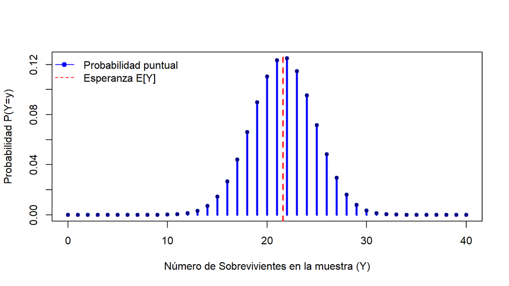

```r
y_vals <- 0:40
prob_y <- dbinom(y_vals, size = 40, prob = p_exito)

plot(y_vals, prob_y, type = "h", lwd = 3, col = "blue",
     xlab = "Número de Sobrevivientes en la muestra (Y)",
     ylab = "Probabilidad P(Y=y)",
     col.main = "darkblue")
points(y_vals, prob_y, pch = 19, col = "darkblue", cex = 0.8)

abline(v = 40 * p_exito, col = "red", lty = 2, lwd = 2)
legend("topleft", legend = c("Probabilidad puntual", "Esperanza E[Y]"),
       col = c("blue", "red"), lty = c(1, 2), pch = c(19, NA), bty = "n")
```

### 4.3.2 NIVEL DE RIESGO

Utilizaremos la variable `RIESGO_CLINICO` para estimar la tasa promedio de incidencia temporal y construir un modelo de Poisson (eventos en un intervalo de tiempo).

- **Definición del Evento:** Ingreso hospitalario de un paciente con riesgo “Alto (5-6)”.
- **Experimento:** Contabilizar el ingreso de pacientes con riesgo alto durante el intervalo de **una semana epidemiológica**.
- **Variable aleatoria ($X$):**
  $$X = \text{Número de pacientes con riesgo alto que ingresan por semana}$$
- **Modelo candidato:** **Poisson**, porque modela el conteo de eventos independientes en un intervalo de tiempo continuo a una tasa promedio constante ($\lambda$).
  $$X \sim \text{Poisson}(\lambda)$$

#### 4.3.2.1 Cálculo del Parámetro ($\lambda$)

Estimamos el promedio de ingresos semanales usando las 52 semanas del año 2021.

**Mostrar / ocultar código**

```r
total_altos <- sum(DATOS_FINALES$RIESGO_CLINICO == "Alto (5-6)", na.rm = TRUE)
lambda_semana <- total_altos / 52
cat("Tasa promedio de ingresos con riesgo alto por semana (lambda):", round(lambda_semana, 4), "\n")
```

```
Tasa promedio de ingresos con riesgo alto por semana (lambda): 2.5769
```

#### 4.3.2.2 Ejemplos de Aplicación (Cálculo de Probabilidades)

Asumiendo el modelo $X \sim \text{Poisson}(2.5769)$:

##### 4.3.2.2.1 Probabilidad Puntual

Probabilidad de recibir exactamente 3 pacientes con riesgo alto en una semana.
$$P(X = 3)$$

**Mostrar / ocultar código**

```r
prob_pois_puntual <- dpois(x = 3, lambda = lambda_semana)
cat("P(X = 3) =", round(prob_pois_puntual, 4))
```

```
P(X = 3) = 0.2168
```

Existe un 21.68% de probabilidad de tener exactamente 3 ingresos de riesgo alto en una semana.

##### 4.3.2.2.2 Probabilidad Acumulada

Probabilidad de recibir como máximo 4 pacientes con riesgo alto semanales.
$$P(X \le 4) = P(X=0) + ... + P(X=4)$$

**Mostrar / ocultar código**

```r
prob_pois_acumulada <- ppois(q = 4, lambda = lambda_semana)
cat("P(X <= 4) =", round(prob_pois_acumulada, 4))
```

```
P(X <= 4) = 0.8807
```

Hay un 88.07% de probabilidad de que los ingresos de riesgo alto no superen los 4 pacientes por semana.

#### 4.3.2.3 Validación Gráfica

**Mostrar / ocultar código**

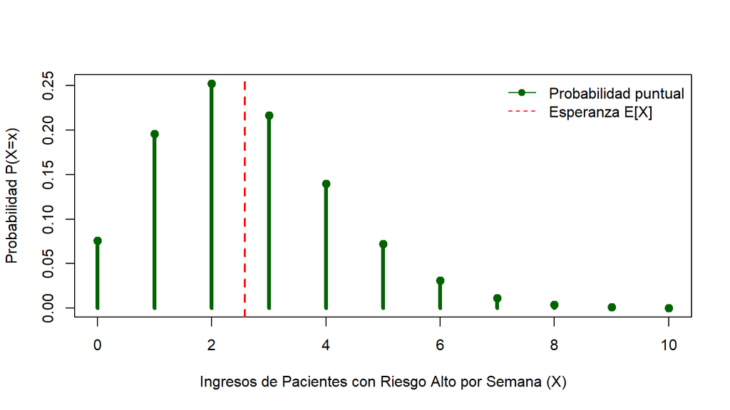

```r
max_x <- max(8, qpois(0.9999, lambda = lambda_semana))
x_vals <- 0:max_x
prob_x <- dpois(x_vals, lambda = lambda_semana)

plot(x_vals, prob_x, type = "h", lwd = 4, col = "darkgreen",
     xlab = "Ingresos de Pacientes con Riesgo Alto por Semana (X)",
     ylab = "Probabilidad P(X=x)",
     col.main = "darkgreen")
points(x_vals, prob_x, pch = 19, col = "darkgreen", cex = 1.2)

abline(v = lambda_semana, col = "red", lty = 2, lwd = 2)
legend("topright", legend = c("Probabilidad puntual", "Esperanza E[X]"),
       col = c("darkgreen", "red"), lty = c(1, 2), pch = c(19, NA), bty = "n")
```

> **Interpretación:** Al enfocar el modelo en los pacientes con riesgo alto, la gráfica muestra cómo la probabilidad se distribuye en torno a la esperanza matemática (línea roja), decayendo progresivamente hacia la derecha. Esto permite a la gestión hospitalaria prever la variabilidad de la demanda semana a semana.

## 4.4 Variables Aleatorias Continuas

### 4.4.1 SCORE_RIESGO_COVID

- **Experimento:** Seleccionar un paciente al azar de `DATOS_FINALES` y registrar su score de riesgo.
- **Variable aleatoria ($X$):**
  $$X = \text{Score de riesgo COVID del paciente seleccionado}$$
- **Rango observado:** La variable es continua en el intervalo positivo ($X>0$).
- **Modelo candidato:** **Gamma**. Se postula este modelo por su capacidad teórica para representar variables estrictamente positivas con asimetría derecha.
  $$X \mid (X>0) \sim \Gamma(k,\theta)$$

#### 4.4.1.1 Análisis Descriptivo y Validación Teórica

Estimamos los parámetros Forma ($k$) y Escala ($\theta$) mediante el Método de Momentos. Dado que este enfoque iguala matemáticamente la realidad empírica con la distribución, presentamos directamente las propiedades teóricas de nuestro modelo ajustado:

**Tabla 12**

**Mostrar / ocultar código**

```r
x_var <- DATOS_FINALES$SCORE_RIESGO_COVID
x_var <- x_var[is.finite(x_var)]
p0 <- mean(x_var == 0)
x_pos <- x_var[x_var > 0]

mx <- mean(x_pos)
vx <- var(x_pos)

# Estimadores Gamma (Método de Momentos)
k_hat <- mx^2 / vx
theta_hat <- vx / mx

# Tabla unificada: Solo mostramos las propiedades teóricas del modelo ajustado
resumen_gamma <- data.frame(
  Propiedad_Teorica = c("Media (E[X])", "Varianza (V(X))", "Desv. Estándar", "Asimetría"),
  Valor_Ajustado = c(k_hat*theta_hat, k_hat*theta_hat^2, sqrt(k_hat*theta_hat^2), 2/sqrt(k_hat))
)

kbl(resumen_gamma, digits = 4, align = "c",
    caption = NULL) |>
  kable_styling(bootstrap_options = c("striped", "hover"), full_width = FALSE)
```

| Propiedad_Teorica | Valor_Ajustado |
| --- | --- |
| Media (E[X]) | 0.5261 |
| Varianza (V(X)) | 0.0804 |
| Desv. Estándar | 0.2835 |
| Asimetría | 1.0777 |

#### 4.4.1.2 Validación Gráfica (Histograma y QQ-Plot)

**Figura 13**

*Densidad Empírica vs Teórica (Gamma)*

**Mostrar / ocultar código**

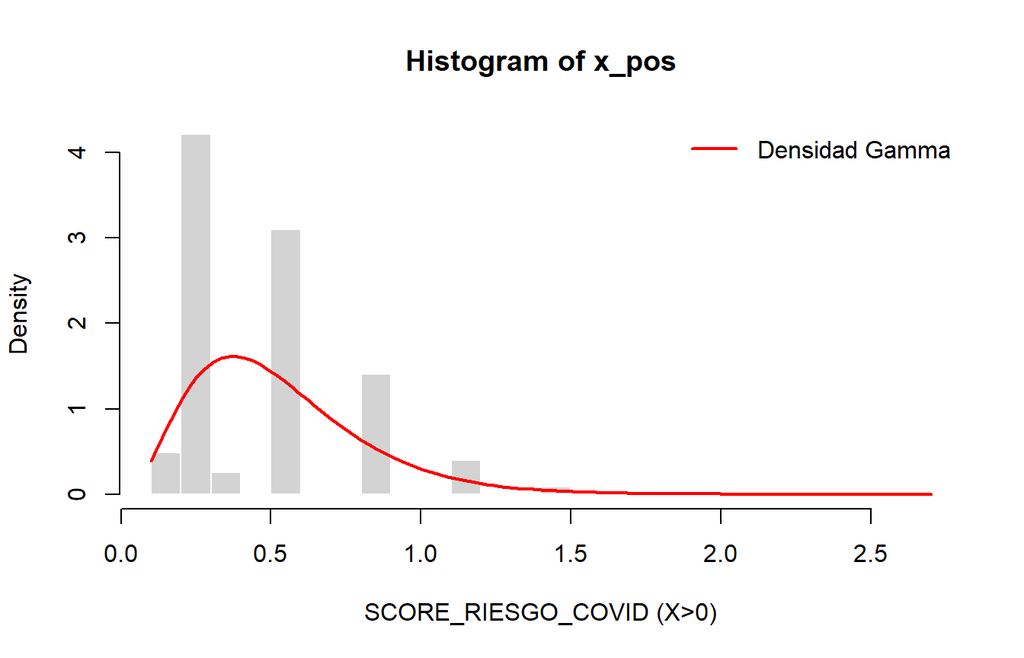

```r
hist(x_pos, breaks = 30, probability = TRUE,
     xlab = "SCORE_RIESGO_COVID (X>0)", col = "lightgray", border = "white")
curve(dgamma(x, shape = k_hat, scale = theta_hat), add = TRUE, col = "red", lwd = 2)
legend("topright", legend = "Densidad Gamma", col = "red", lwd = 2, bty = "n")
```

**Figura 14**

*Q-Q Plot: Ajuste Gamma*

**Mostrar / ocultar código**

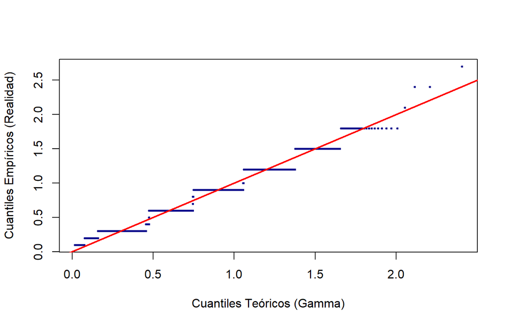

```r
p_teo <- ppoints(length(x_pos))
q_teo <- qgamma(p_teo, shape = k_hat, scale = theta_hat)
q_emp <- sort(x_pos)

plot(q_teo, q_emp,
     xlab = "Cuantiles Teóricos (Gamma)", ylab = "Cuantiles Empíricos (Realidad)",
     col = "darkblue", pch = 20, cex = 0.5)
abline(0, 1, col = "red", lwd = 2)
```

> **Interpretación:** Los puntos azules se adhieren de forma sumamente sólida a la línea diagonal roja (identidad) en la inmensa mayoría de la distribución. Las ligeras desviaciones en la cola superior son un comportamiento esperado frente a casos atípicos extremos, pero no invalidan el excelente ajuste general del modelo.

#### 4.4.1.3 Ejemplos de Aplicación (Cálculo en Intervalos)

**Pregunta**: ¿Cuál es la probabilidad de que el score de un paciente se encuentre entre 0.5 y 1.5?
$$P(0.5 \le X \le 1.5) = F(1.5) - F(0.5)$$

**Mostrar / ocultar código**

```r
prob_intervalo_gamma <- pgamma(1.5, shape = k_hat, scale = theta_hat) -
                        pgamma(0.5, shape = k_hat, scale = theta_hat)
cat("P(0.5 <= X <= 1.5) =", round(prob_intervalo_gamma, 4))
```

```
P(0.5 <= X <= 1.5) = 0.4591
```

Existe un 45.9% de probabilidad teórica de que el paciente se encuentre en este rango.